# Problem Set 3

Author

Taeyoung Heo (UMID # 2914 5801)

GitHub repository link : https://github.com/tedheo10/HW3_STATS506

## Probmlem 1 - Vision

**P1-a.** Merge the two files, VIX_D and DEMO_D

```r
library(foreign) # a package to import ".XPT" file

demo <- read.xport("DEMO_D.XPT") # DEMO_D file import
vix <- read.xport("VIX_D.XPT") # VIX_D file import

merge_data <- merge(demo, vix, by = "SEQN", all = FALSE) # merge data
n <-nrow(merge_data) # the number of data
print(n)
```

```
[1] 6980
```

**P1-b.** The proportion table of respondents who wear glasses/contact lenses for distance vision

```r
library(stargazer) # a package to generate HTML/LaTeX tables
# Empty matrix only with a columen of age ranges
mat_glasses <- matrix(nrow = 10, ncol = 3)
colnames(mat_glasses) <- c("AgeRange", "Count", "Proportion")
mat_glasses[,1] <- c("0-9", "10-19", "20-29", "30-39", "40-49", "50-59", "60-69", "70-79", "over 80", "Total")

# Populate the count of people who wear glasses/contact lenses for distance vision
for (i in 1:10) {
  if(i<10) {
    mat_glasses[i,2] <- sum(merge_data$VIQ220 == 1 &
        merge_data$RIDAGEYR < 10*i & merge_data$RIDAGEYR >= 10*(i-1), na.rm = TRUE)
    }
  else if(i==10) {
    mat_glasses[i,2] <- sum(merge_data$VIQ220 == 1, na.rm = TRUE)
  }
}

# Populate the proportion of people in each age group
for (i in 1:10) {
    each_group <- as.numeric(mat_glasses[i,2])
    total_group <- as.numeric(mat_glasses[10,2])
    mat_glasses[i,3] <- each_group / total_group
}

# Change the mat_glasses as a data.frame with numeric values
df_glasses <- as.data.frame(mat_glasses)
df_glasses[,2] <- as.numeric(df_glasses[,2])
df_glasses[,3] <- as.numeric(df_glasses[,3])

#  Table by ussing stargazer
table_glasses <- stargazer(df_glasses, type = "text", summary = FALSE,
  rownames = TRUE, title = "Glasses and Contact lenses Usage for Distance Vision")
```

```
Glasses and Contact lenses Usage for Distance Vision
============================
   AgeRange Count Proportion
----------------------------
1    0-9      0       0
2   10-19    670    0.242
3   20-29    306    0.111
4   30-39    269    0.097
5   40-49    286    0.103
6   50-59    335    0.121
7   60-69    392    0.142
8   70-79    299    0.108
9  over 80   208    0.075
10  Total   2,765     1
----------------------------
```

**P1-c.** Fit three logistic regression models predicting whether a respondent wears glasses/contact lenses for distance vision  
1. the 1st logistic regression with age as a predictor

```r
merge_data$VIQ220_BI <- merge_data$VIQ220 == 1 # Binomial data for VIQ220
glm1 <- glm(VIQ220_BI ~ RIDAGEYR, data = merge_data, family = binomial)
odd_1 <- exp(coef(glm1)) # the oods ratios
num1 <- nobs(glm1) # sample size
pseudo_r1 <- 1 - (glm1$deviance / glm1$null.deviance) # pseudo-R^2
aic1 <- AIC(glm1) # AIC value
```

2. the 2nd logistic regression with age, race and gender as predictors

```r
glm2 <- glm(VIQ220_BI ~ RIDAGEYR+RIDRETH1+RIAGENDR, data=merge_data, family = binomial)
odd_2 <- exp(coef(glm2)) # the oods ratios
num2 <- nobs(glm2) # sample size
pseudo_r2 <- 1 - (glm2$deviance / glm2$null.deviance) # pseudo-R^2
aic2 <- AIC(glm2) # AIC value
```

3. the 3rd logistic regression with age, race, gender and poverty income ratio as predictors

```r
glm3 <- glm(VIQ220_BI ~ RIDAGEYR+RIDRETH1+RIAGENDR+INDFMPIR, data=merge_data, family = binomial)
odd_3 <- exp(coef(glm3)) # the oods ratios
num3 <- nobs(glm3) # sample size
pseudo_r3 <- 1 - (glm2$deviance / glm2$null.deviance) # pseudo-R^2
aic3 <- AIC(glm3) # AIC value
```

4. a summary table of the three logistic models

```r
summary_table <- data.frame(
  Model_1 = c(odd_1[2], NA, NA, NA, num1, pseudo_r1, aic1),
  Model_2 = c(odd_2[2], odd_2[3], odd_2[4], NA, num2, pseudo_r2, aic2),
  Model_3 = c(odd_3[2], odd_3[3], odd_3[4], odd_3[5], num3, pseudo_r3, aic3),
  row.names = c("Odd_Ratio_Age", "Odd_Ratio_Race", "Odd_Ratio_Gender", "Odd_Ratio_PIR", "Sample_Size", "Pseudo_R2", "AIC")
)

stargazer(summary_table, type = "text", summary = FALSE, title = "Summary of the three Logistic Regression Models")
```

```
Summary of the three Logistic Regression Models
==============================================
                  Model_1   Model_2   Model_3
----------------------------------------------
Odd_Ratio_Age      1.025     1.025     1.024
Odd_Ratio_Race               1.133     1.098
Odd_Ratio_Gender             1.644     1.678
Odd_Ratio_PIR                          1.153
Sample_Size        6,547     6,547     6,249
Pseudo_R2          0.050     0.063     0.063
AIC              8,477.679 8,360.491 7,943.021
----------------------------------------------
```

**P1-d.** From glm3, test and interpretation  
1. Test whether the odds of men and women being wears of glasess/contact lenses for distance vision differs.  
: **the p-value of t-test for the coefficient for the gender variable(RIAGENDR) is very small(p-value = 1.153700e-21). This means that the odds between men and women are significantly different.**

```r
summary(glm3)$coeff["RIAGENDR", ] # the test of the coefficient for RIAGENDR
```

```
    Estimate   Std. Error      z value     Pr(>|z|)
5.174490e-01 5.411447e-02 9.562119e+00 1.153700e-21
```

2. Test whether the proportion of wearers of glasses/contact lenses for distance vision differs between men and women.  
   : **the p-value of chi-squared test for the proportion between males and females is very small(p-value < 2e-16). This means that the proportions between men and women are significantly different.**

```r
pp_table <- table(merge_data$RIAGENDR, merge_data$VIQ220_BI)
pp_table[1,2]/sum(pp_table[1,]) # the proportion of male
```

```
[1] 0.3696401
```

```r
pp_table[2,2]/sum(pp_table[2,]) # the proportion of female
```

```
[1] 0.4725537
```

```r
chi_test <- chisq.test(pp_table) # the chi-squared test for the proportion difference
chi_test
```

```
    Pearson's Chi-squared test with Yates' continuity correction

data:  pp_table
X-squared = 70.593, df = 1, p-value < 2.2e-16
```

## Problem 2 - Sakila

**P2-a.** the year of the oldest movie and the number of movies from that year  
: **the year = 2006** and **the number of movies = 1,000**

```r
library(DBI)
library(RSQLite)

sakila <- dbConnect(SQLite(), "sakila_master.db")

# This function is used to apply SQL to the Sakila database
sakila_sql <- function(query) {
   # this code is from the class notes for STATS 506
  dbGetQuery(sakila, query)
}

# This is the query for the answer of this problem
sakila_sql("
SELECT COUNT(film_id), release_year
  FROM film
 GROUP BY release_year
HAVING release_year = MIN(release_year)
")
```

```
  COUNT(film_id) release_year
1           1000         2006
```

**P2-b.** the least common genre and the number of movies in that genre  
: **the genre = Music** and **the number of movies = 51**  
1. regular R operations

```r
category_data <- sakila_sql("
                  SELECT category_id, name
                    FROM category
                 ")
film_data <- sakila_sql("
              SELECT film_id, category_id
                FROM film_category
              ")
film_data <- merge(film_data, category_data, by = "category_id", all.x=TRUE)
category_table <- table(film_data$name) # the category table of genre
min_index <- which.min(category_table) # index for the least common genre
category_table[min_index] # at least common genre and the number of the movies
```

```
Music
   51
```

2. a single SQL query

```r
sakila_sql("
SELECT c.name, COUNT(fc.film_id) AS count
  FROM film_category AS fc
  LEFT JOIN category AS c on fc.category_id = c.category_id
 GROUP BY fc.category_id
 ORDER BY count
 LIMIT 1
")
```

```
   name count
1 Music    51
```

**P2-c.** Countries with exactly 13 customers  
: **the countries are Argentina and Nigeria**  
1. regular R operations

```r
# estract data from tables
country_data <- sakila_sql("
                 SELECT country_id, country
                   FROM country
                ")
city_data <- sakila_sql("
              SELECT city_id, country_id
                FROM city
             ")
address_data <- sakila_sql("
                 SELECT address_id, city_id
                   FROM address
                ")
customer_data <- sakila_sql("
                  SELECT customer_id, address_id
                    FROM customer
                 ")

# data merger into one data frame "customer_data"
customer_data <- merge(customer_data, address_data, by = "address_id", all.x = TRUE)
customer_data <- merge(customer_data, city_data, by = "city_id", all.x = TRUE)
customer_data <- merge(customer_data, country_data, by = "country_id", all.x = TRUE)

# coutries with exactly 13 customers
country_table <- table(customer_data$country)
index13 <- which(country_table==13)
country_table[index13]
```

```
Argentina   Nigeria
       13        13
```

2. a single SQL query

```r
sakila_sql("
SELECT acn.country, COUNT(cu.customer_id) AS customer
  FROM customer as cu
  LEFT JOIN (
      SELECT a.address_id, cn.country
        FROM address AS a
        LEFT JOIN (
            SELECT c.city_id, c.country_id, n.country
              FROM city as c
              LEFT JOIN country AS n on c.country_id=n.country_id
             ) AS cn on cn.city_id = a.city_id
        ) AS acn on acn.address_id = cu.address_id
 GROUP BY country
HAVING COUNT(cu.customer_id) = 13
      ")
```

```
    country customer
1 Argentina       13
2   Nigeria       13
```

## Problem 3 - US Records

**P3-a.** the proportion of email addresses with TLD “.com”  
: **the proportion = 0.732**

```r
us500 <- read.csv("us-500.csv")
email_us <- us500$email
total <- length(email_us) # total number of email addresses
com <- email_us[grepl("@.+\\.com",email_us)]
sub <- length(com) # the number of email addresses with TLD ".com"
sub/total # the proportion of email addresses with TLD “.com”
```

```
[1] 0.732
```

**P3-b.** the proportion of email addresses with at least one non alphanumeric character  
: **the proportion = 0.506**

```r
non <- email_us[grepl("[^a-zA-Z0-9].*@.+\\..+",email_us)]
sub2 <- length(non) # the number of email addresses with a non alphanumeric character
sub2/total # the proportion of email addresses with a non alphanumeric character
```

```
[1] 0.506
```

**P3-c.** the top 5 most common area codes amongst all phone numbers  
: **the top 5 area codes are 973, 212, 215, 410 and 201**

```r
phone1_us <- us500$phone1
phone2_us <- us500$phone2
area1 <- substr(phone1_us, 1, 3) # the area code from phone1
area2 <- substr(phone2_us, 1, 3) # the area code from phone2
area_table <- table(area1)
area_sorted <- sort(area_table, decreasing = TRUE)
names(head(area_sorted, 5)) # the 5 most common area codes amongt all phone numbers
```

```
[1] "973" "212" "215" "410" "201"
```

**P3-d.** a histogram of the log of the apartment numbers for all addresses

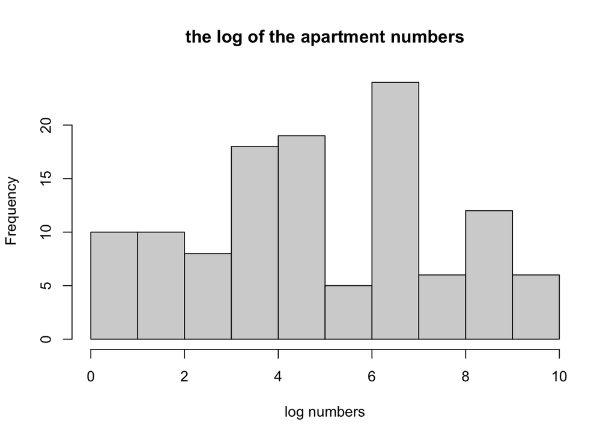

```r
address <- us500$address
apt_num <- regmatches(address, regexpr("\\d+$", address)) # any number at the end of the an address
apt_num <- as.numeric(apt_num)
log_num <- log(apt_num) # the log of the apartment numbers
hist(log_num, main = "the log of the apartment numbers", xlab = "log numbers")
```

**P3-e.** Examination whether the apartment numbers appear to follow Benford’s law  
: the chi-squared test p-value = 1.158e-08  
We can reject the hypothesis that the apartment numbers follow Benford’s law.

```r
chr <- as.character(apt_num)
digit <- substr(chr,1,1) # the leading digit of the apartment numbers
digit <- as.numeric(digit)
count <- table(digit) # the number of the leading digit
ben_p <- log10(1+(1/1:9)) # the probability from Benford's law
chisq.test(count, p = ben_p) # test for compliance with Benford's law
```

```
    Chi-squared test for given probabilities

data:  count
X-squared = 52.84, df = 8, p-value = 1.158e-08
```